# AE 08: Inference for Multiple Linear Regression

Rail Trails

**Important**

- Open [RStudio](https://rstudio.collegeofidaho.edu/) and create a subfolder in your AE folder called “AE-08”.
- Go to the [Canvas](https://cofi.instructure.com/courses/17093/assignments/202839) and locate your `AE-08` assignment to get started.
- Upload the `ae-08.qmd` and `rail-trail.csv` files into the folder you just created.

## Packages + data

```r
library(tidyverse)
library(ggformula)
library(broom)
library(knitr)
library(mosaic)
library(mosaicData)

rail_trail <- read_csv("~/MAT-212/AE-08/rail_trail.csv")
head(rail_trail)
```

```
# A tibble: 6 × 7
  volume hightemp avgtemp season cloudcover precip day_type
   <dbl>    <dbl>   <dbl> <chr>       <dbl>  <dbl> <chr>
1    501       83    66.5 Summer       7.60 0      Weekday
2    419       73    61   Summer       6.30 0.290  Weekday
3    397       74    63   Spring       7.5  0.320  Weekday
4    385       95    78   Summer       2.60 0      Weekend
5    200       44    48   Spring      10    0.140  Weekday
6    375       69    61.5 Spring       6.60 0.0200 Weekday
```

The data for this AE is based on data from the Pioneer Valley Planning Commission (PVPC) and is included in the **mosaicData** package. The PVPC collected data for ninety days from April 5, 2005 to November 15, 2005. Data collectors set up a laser sensor, with breaks in the laser beam recording when a rail-trail user passed the data collection station. More information can be found [here](http://www.fvgreenway.org), [here](https://www.trafx.net/), and [here](https://fchtrail.org/wp-content/uploads/2021/07/FVTC-Trail-Usage-Study-2013-15.pdf).

**Response**

- `volume`: Number bikes that broke the laser beam

## Analysis goal

The goals of this activity are to:

- Perform inference for multiple linear regression
- Conduct/interpret hypothesis tests
- Construct/interpret confidence intervals
- Determine whether the conditions for inference are satisfied in this multi-predictor setting.

## Exercise 0

Import `GGally` and use `ggpairs` to plot all combinations of variables.

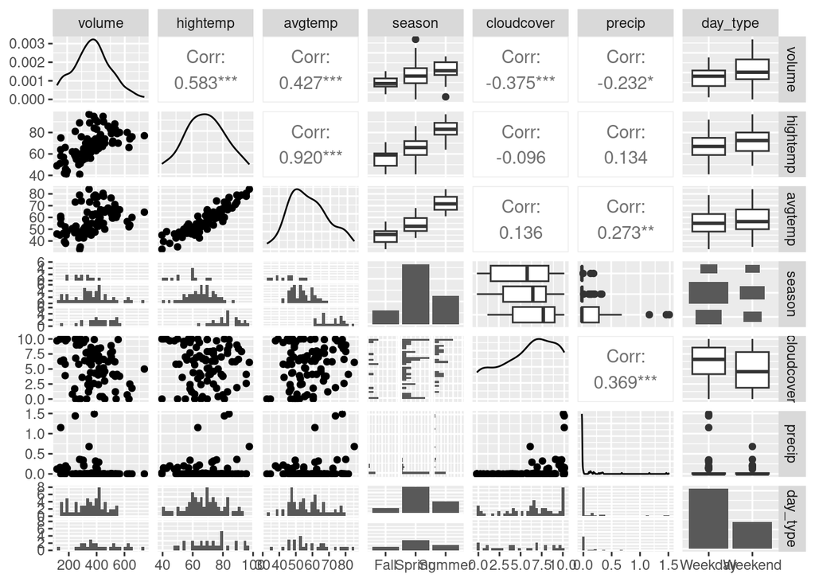

```r
library(GGally)
rail_trail |> ggpairs()
```

## Exercise 1

Choose two explanatory variables which you think will best predict `Volume` based on the plot above. Write your two variables on the board. You may not use the same combination as another group. If you choose a temperature, only select one.

High Temperature and Day type

## Exercise 2

Fit and display two linear regression models predicting `volume` from the two predictors you chose. In one, include an interaction term between the two variables and in the other, do not.

```r
rail_fitr <- lm(volume ~ hightemp + day_type, data = rail_trail)
tidy(rail_fitr) |> kable()
```

| term | estimate | std.error | statistic | p.value |
| --- | --- | --- | --- | --- |
| (Intercept) | -8.746923 | 58.2971018 | -0.1500404 | 0.8810800 |
| hightemp | 5.347817 | 0.8462988 | 6.3190648 | 0.0000000 |
| day_typeWeekend | 51.553496 | 23.6744270 | 2.1776027 | 0.0321423 |

```r
# library(mosaic)
# p1 <- plotModel(lm(volume ~ hightemp*day_type, data = rail_trail))
# p2 <- plotModel(lm(volume ~ hightemp*day_type, data = rail_trail %>% mutate(volume = shuffle(volume))))
# p1 + p2
```

## Exercise 3

Consider the model *without* an interaction term. Perform a hypothesis test on one of your explanatory variables (fill in the blanks where appropriate:

1. **Set hypothesis:** $H_0: \beta_{1} = 0$ vs. $H_A: \beta_{1} \neq 0$, given day_type is in the model. Restate these hypothesis in words: The null hypothesis states that there is no relationship between high_temp and volume given that day_type is in the model.

   The alternative hypothesis states that there is a relationship between high_temp and volume given that day_type is in the model.
2. **Calculate test statistics and p-value:** The test statistic is $6.319064$. The p-value is $0$.
3. **State the conclusion:** According to p value, we have a strong evidence to reject null hypothesis.

## Exercise 4

Consider the model *with* an interaction term. Interpret the the p-value associated with the interaction term.

```r
rail_fit <- lm(volume ~ hightemp + day_type + hightemp * day_type, data = rail_trail)
tidy(rail_fit)
```

```
# A tibble: 4 × 5
  term                     estimate std.error statistic     p.value
  <chr>                       <dbl>     <dbl>     <dbl>       <dbl>
1 (Intercept)                -51.2      70.7     -0.725 0.471
2 hightemp                     5.98      1.03     5.78  0.000000117
3 day_typeWeekend            186.      129.       1.44  0.153
4 hightemp:day_typeWeekend    -1.91      1.80    -1.06  0.292
```

## Exercise 5

Generate 95% confidence intervals for the model *without* an interaction term. Hint: use the `tidy` function with the argument `conf.int = TRUE`. Interpret the confidence interval for the same explanatory variable as Exercise 3 and explain why the combination of p-value and confidence interval makes sense.

```r
tidy(rail_fitr, conf.int = TRUE,level = 0.95)
```

```
# A tibble: 3 × 7
  term            estimate std.error statistic      p.value conf.low conf.high
  <chr>              <dbl>     <dbl>     <dbl>        <dbl>    <dbl>     <dbl>
1 (Intercept)        -8.75    58.3      -0.150 0.881         -125.      107.
2 hightemp            5.35     0.846     6.32  0.0000000109     3.67      7.03
3 day_typeWeekend    51.6     23.7       2.18  0.0321           4.50     98.6
```

We are 95% confident that the slope we get from rail_fitr will fall between 3.665706 to 7.029927.

## Exercise 6

What does it mean for two things to be **independent** in statistics (feel free to use Google)? Do we think our p-values/confidence intervals are **independent** across variables?

## Exercise 7

**Important**

If the intercept term was significant, use that model for the rest of this activity, otherwise use the model without the interaction term.

Generate a scatter plot of the residuals vs. the fitted values for this model.

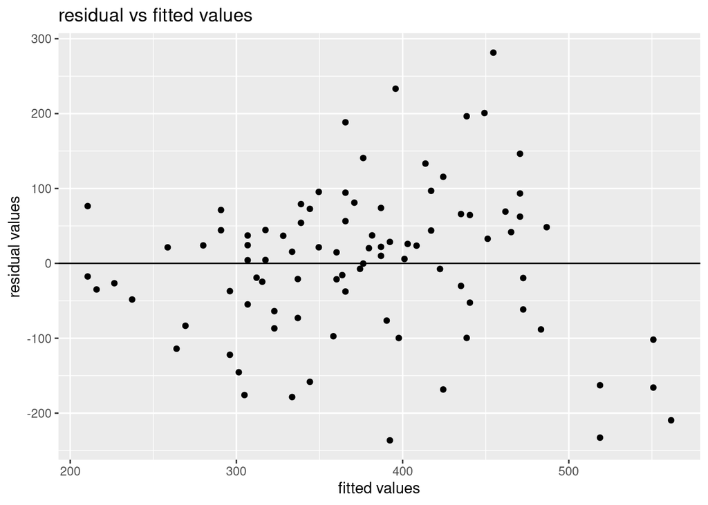

```r
rail_aug <- augment(rail_fitr)

gf_point(.resid ~ .fitted, data = rail_aug) |>
  gf_hline(yintercept = 0) |>
  gf_labs(x = "fitted values", y = "residual values", title = "residual vs fitted values")
```

## Exercise 8

Plot the residuals vs. each of your predictors (two plots total).

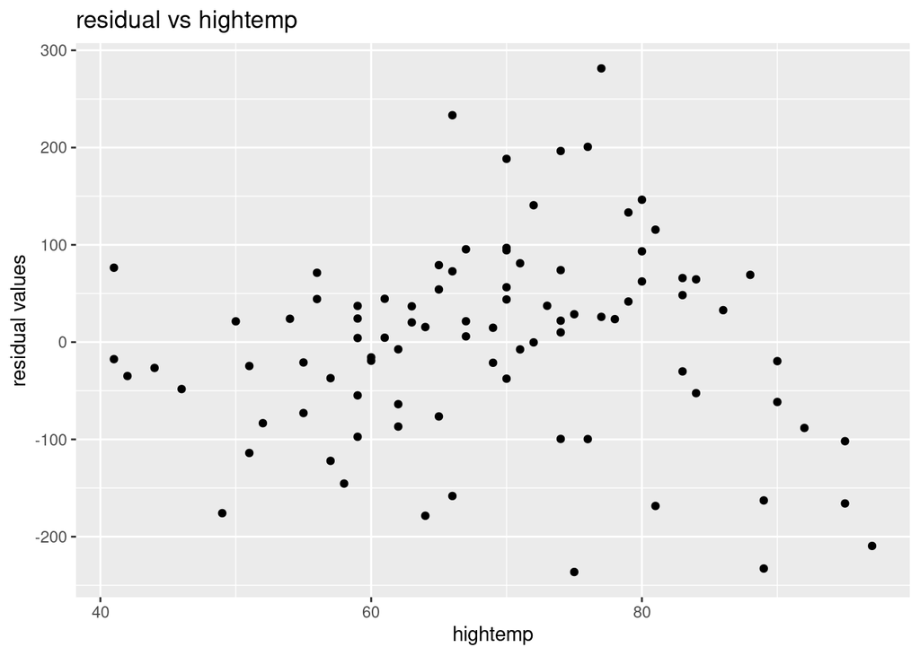

```r
gf_point(.resid ~ hightemp, data= rail_fitr)|>
  gf_labs(x = "hightemp", y = "residual values", title = "residual vs hightemp")
```

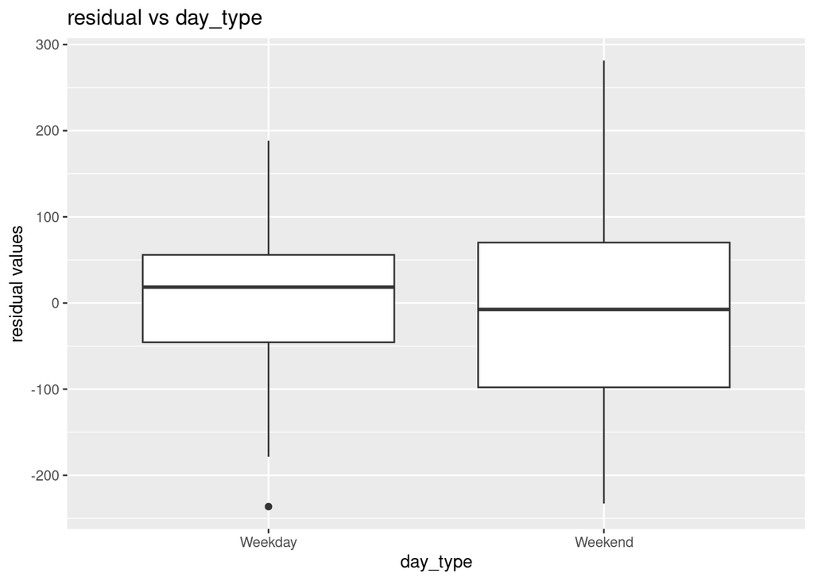

```r
gf_boxplot(.resid ~ day_type, data= rail_fitr) |>
  gf_labs(x = "day_type", y = "residual values", title = "residual vs day_type")
```

## Exercise 9

Based on the three plots you’ve made, do you think the linearity condition is satisfied?

Maybe. Even if we see the linearity then the linearity score will be low maybe around 0.3.

## Exercise 10

We check the constant variance assumption in the same way we do with SLR. To what extent does the constant variance condition seem to be satisfied?

It is not satisfied. We observed curves around the edges.

## Exercise 11

Generate a histogram and QQ-plot of the residuals. To what extent do you believe the normality condition is satisfied?

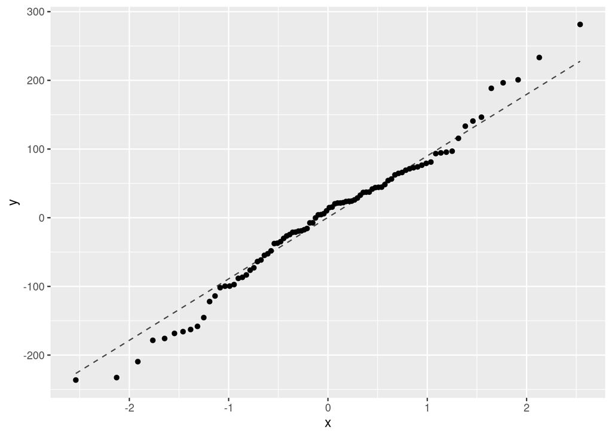

```r
gf_qq(~.resid, data = rail_aug) |>
  gf_qqline()
```

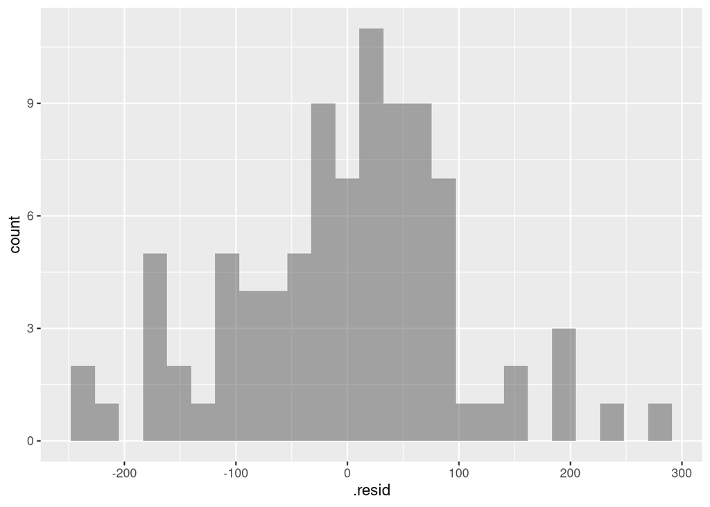

```r
gf_histogram(~.resid, data = rail_aug)
```

In this context, we observed that the normality condition is somewhat met (medium rare- Sadie).

## Exercise 12

How do you think would you go about checking the independence condition?

We would look at how the data was collected. looking at it, we see a lot more spring data this could cause a few problems in inference but not in the linear model. therefore, it is good.

## To submit the AE

**Important**

- Render the document to produce the HTML file with all of your work from today’s class.
- Upload your QMD and HTML files to the Canvas assignment.